# Сердюков Дмитрий

## Лабораторная работа №2

Необходимо было выполнить задания 24 и 11

### Задание №24

#### Условие

Используйте файл Payment_and_value_of_Care-Hospital.csv На основе имеющихся данных создайте dataframe, агрегирующий информацию о количестве больниц в городах США. Dataframe должен содержать 5 колонок: название штата, название округа, название города, количество больниц в этом городе и количество больниц в которых осуществляется экстренная медицинская помощь.

Примечание: файл в репозитории был битый, взял оригинал в инетернете.

#### Решение

Для начала считаем данные:

```r
df <- read.csv('data/Payment_and_Value_of_Care-Hospital.csv')
head(df)
```

```
##   Facility.ID                   Facility.Name                    Address   City
## 1       10001 SOUTHEAST HEALTH MEDICAL CENTER     1108 ROSS CLARK CIRCLE DOTHAN
## 2       10001 SOUTHEAST HEALTH MEDICAL CENTER     1108 ROSS CLARK CIRCLE DOTHAN
## 3       10001 SOUTHEAST HEALTH MEDICAL CENTER     1108 ROSS CLARK CIRCLE DOTHAN
## 4       10001 SOUTHEAST HEALTH MEDICAL CENTER     1108 ROSS CLARK CIRCLE DOTHAN
## 5       10005        MARSHALL MEDICAL CENTERS 2505 U S HIGHWAY 431 NORTH   BOAZ
## 6       10005        MARSHALL MEDICAL CENTERS 2505 U S HIGHWAY 431 NORTH   BOAZ
##   State ZIP.Code County.Name   Phone.Number Payment.Measure.ID
## 1    AL    36301     HOUSTON (334) 793-8701        PAYM_30_AMI
## 2    AL    36301     HOUSTON (334) 793-8701         PAYM_30_HF
## 3    AL    36301     HOUSTON (334) 793-8701         PAYM_30_PN
## 4    AL    36301     HOUSTON (334) 793-8701   PAYM_90_HIP_KNEE
## 5    AL    35957    MARSHALL (256) 593-8310        PAYM_30_AMI
## 6    AL    35957    MARSHALL (256) 593-8310         PAYM_30_HF
##                        Payment.Measure.Name
```

[output cut: 34 more lines]

Далее я сразу нахожу такие строчки, из которых смогу определить, оказывается ли в больнице экстренная помощь (экстренной я считаю остановку сердца или сердечный приступ):

```r
emergency_df <- df[
  ((df$Payment.Measure.Name == 'Payment for heart attack patients') |
  (df$Payment.Measure.Name == 'Payment for heart failure patients')) , ]
```

Нахожу больницы как подмножество уникальных записей, отобрав нужные столбцы:

```r
hospitals <- unique(subset(df, select = c(
    'State',
    'County.Name',
    'City',
    'Facility.Name'
    )
  ))
```

Группирую больницы по штату, округу и городу, чтобы найти количество больниц в каждом городе

```r
hospitals <- aggregate(hospitals$Facility.Name,
               by = list(
                  State = hospitals$State,
                  County = hospitals$County.Name,
                  City = hospitals$City),
               FUN = length)
```

```r
hospitals_emergency <- subset(emergency_df, select = c(
      'State',
      'County.Name',
      'City',
      'Payment.Footnote'
    )
  )


fun <- function(x) {
  if (x == '') {
    1
  } else {
    0
  }
}

hospitals_emergency$Payment.Footnote <- as.integer(lapply(hospitals_emergency$Payment.Footnote, fun))
```

Это для того, чтобы потом группировать как сумму (округляю и делю на 2 так как учитываю по двум параметрам - heart attack и heart failure):

```r
hospitals_emergency <- aggregate(hospitals_emergency$Payment.Footnote,
                       by = list(
                         State = hospitals_emergency$State,
                         County = hospitals_emergency$County.Name,
                         City = hospitals_emergency$City),
                       FUN = function(x) floor(sum(x) / 2 + 0.5))
```

Затем я горизонтально соединяю эти датафреймы и именную столбы:

```r
result <- cbind(hospitals, hospitals_emergency$x)
colnames(result) <- c('State', 'Country', 'City', 'Hospitals Total', 'Hospitals with Emergency Services')
head(result, 10)
```

```
##    State      Country      City Hospitals Total
## 1     SC    ABBEVILLE ABBEVILLE               1
## 2     LA    VERMILION ABBEVILLE               1
## 3     SD        BROWN  ABERDEEN               2
## 4     WA GRAYS HARBOR  ABERDEEN               1
## 5     MS       MONROE  ABERDEEN               1
## 6     KS    DICKINSON   ABILENE               1
## 7     TX       TAYLOR   ABILENE               1
## 8     VA   WASHINGTON  ABINGDON               1
## 9     PA   MONTGOMERY  ABINGTON               1
## 10    MS      CHOCTAW  ACKERMAN               1
##    Hospitals with Emergency Services
## 1                                  0
## 2                                  1
## 3                                  2
## 4                                  1
## 5                                  0
## 6                                  0
## 7                                  1
## 8                                  1
## 9                                  1
## 10                                 0
```

### Задание №11

#### Условие

Используйте файл RH_T.csv Напишите функцию, которая находит 2 соседних дня с максимальным перепадом температуры.

Примечание: файл в репозитории был битый, взял оригинал в инетернете.

#### Решение

Считываю данные:

```r
df <- read.csv('data/RH_T.csv')
head(df)
```

```
##   X   LON   LAT YEAR MM DD DOY   YYYYMMDD  RH2M    T2M PRECTOTCORR
## 1 1 60.59 56.84 2020  1  1   1 2020-01-01 99.06  -9.49        0.44
## 2 2 60.59 56.84 2020  1  2   2 2020-01-02 98.94 -12.16        2.17
## 3 3 60.59 56.84 2020  1  3   3 2020-01-03 99.06 -15.93        1.52
## 4 4 60.59 56.84 2020  1  4   4 2020-01-04 98.38  -7.49        1.08
## 5 5 60.59 56.84 2020  1  5   5 2020-01-05 99.06  -6.70        0.07
## 6 6 60.59 56.84 2020  1  6   6 2020-01-06 99.38  -7.72        0.06
```

Затем составил функцию, которая находит два дня рядом с максимальной разницей:

```r
find_max_diff <- function(df) {
  max_diff <- 0
  max_i <- 2
  for (i in 2:nrow(df)) {
    dt <- abs(as.numeric(df$T2M[i - 1]) - as.numeric(df$T2M[i]))
    if (dt > max_diff) {
      max_diff <- dt
      max_i = i
    }
  }
  return(df[c(max_i-1, max_i), ])
}
```

Проверим функцию на наших данных:

```r
find_max_diff(df)
```

```
##       X   LON   LAT YEAR MM DD DOY   YYYYMMDD  RH2M    T2M PRECTOTCORR
## 353 353 60.59 56.84 2020 12 18 353 2020-12-18 97.50 -10.49        2.60
## 354 354 60.59 56.84 2020 12 19 354 2020-12-19 98.31 -20.87        0.04
```

Как видим, нашлись два дня с максимальным перепадом температупр

## Лабораторная работа №3

Необходимо было выполнить задания 10 и 1

### Задание №10

#### Условие

Файл: *reforest.csv* Примечание: данного файл вообще нет, нашел его где-то в интернете (это было непросто).

Удалите строки, в которых есть пропущенные значения и приведите данные к формату tidydata. Отобразите динамику лесовосстановления по годам с помощью линейного графика для любого из федеральных округов, просуммировав значения соотвествующих субъектов федерации. Подпишите значения на графике. Для минимального значения сделайте подпись красным цветом. Отрегулируйте местоположение подписей так, чтобы рисунок был максимально наглядным. Придумайте новые назания графика и осей.

#### Решение

Для начала считаем данные:

```r
library(tidyverse)
reforest = read_csv2('data/reforest.csv')
```

```
## ℹ Using "','" as decimal and "'.'" as grouping mark. Use `read_delim()` for more control.
```

```r
head(reforest)
```

```
## # A tibble: 6 × 9
##   Region                 `2005` `2010` `2011` `2012` `2013` `2014` `2015` `2016`
##   <chr>                   <dbl> <chr>  <chr>  <chr>  <chr>  <chr>  <chr>  <chr>
## 1 Российская Федерация    812.  811,5  860    841,7  872,3  863    802,9  839,9
## 2 Центральный федеральн…   52.6 62,7   60,9   60,3   70,9   71,2   72,6   77
## 3 Белгородская область      0.4 0,1    0,3    0,3    0,4    0,4    0,2    0,2
## 4 Брянская область          2.9 2,8    3      3,2    3,5    3,3    3,1    3
## 5 Владимирская область      4.4 5,3    5,7    6      7,1    5,9    6      4,9
## 6 Воронежская область       1.1 1,1    1,8    3      2,7    2,7    2,6    2,3
```

Теперь удалим все пустые строчки (также удаляю строчки, где есть странные значения: ‘…2)’ или ‘-’)

```r
reforest <- reforest[rowSums(
    !is.na(reforest) &
    reforest[,] != '…2)' &
    reforest[,] != '-'
    ) == ncol(reforest), ]
```

В файле неправильный десятичный разделитель где-то попадается, поэтому меняю запятую на точку и привожу к численному типу:

```r
reforest[, c(2:ncol(reforest))] <- sapply(reforest[, c(2:ncol(reforest))],
                                          function(x) as.double(gsub(",", ".", x)))
```

После этого к тубблу:

```r
reforest <- as_tibble(reforest)
```

Я решил взять Северо-западный федеральный округ, поэтому выписываю регионы, которые входят в него и фильтрую таблицу по ним. Далее я считаю суммарные значения по всем годам и прибавляю к названию региона с пометкой “суммарно:”. После этого я привожу данные в таблице к “длинному” виду с помощью pivot_longer для удобства построения графика.

```r
need_regions = c(
  'Республика Карелия',
  'Республика Коми',
  'Архангельская область',
  'Вологодская область',
  'Новгородская область',
  'Псковская область'
)

reforest <- reforest %>%
  filter(Region %in% need_regions) %>%
  mutate(Region = paste(
    Region, '( суммарно:', rowSums(across(where(is.numeric))), ')')) %>%
  pivot_longer(cols = `2005`:`2016`,
               names_to = 'year',
               values_to = "value")

head(reforest, 10)
```

```
## # A tibble: 10 × 3
##    Region                                 year  value
##    <chr>                                  <chr> <dbl>
##  1 Республика Карелия ( суммарно: 158.9 ) 2005   27.7
##  2 Республика Карелия ( суммарно: 158.9 ) 2010   23.9
##  3 Республика Карелия ( суммарно: 158.9 ) 2011   19.9
##  4 Республика Карелия ( суммарно: 158.9 ) 2012   19
##  5 Республика Карелия ( суммарно: 158.9 ) 2013   17.9
##  6 Республика Карелия ( суммарно: 158.9 ) 2014   16.8
##  7 Республика Карелия ( суммарно: 158.9 ) 2015   16.5
##  8 Республика Карелия ( суммарно: 158.9 ) 2016   17.2
##  9 Республика Коми ( суммарно: 286.1 )    2005   25.7
## 10 Республика Коми ( суммарно: 286.1 )    2010   33.3
```

Сторю график, помечая регион с минимальным значением (Псковская область) красным цветом на графике.

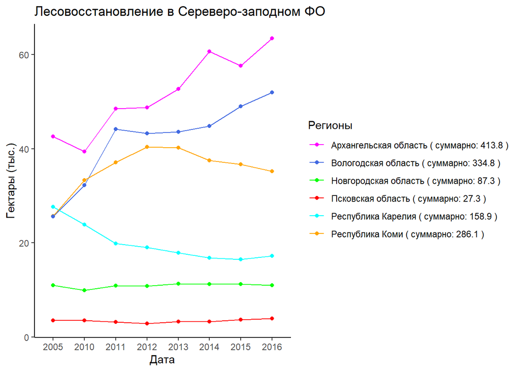

```r
ggplot(reforest, aes(x = year, y = value, group = Region)) +
  geom_line(aes(color = Region)) +
  geom_point(aes(color = Region)) +
  scale_colour_manual(values =
                        c('magenta','royalblue','green','red','cyan','orange')) +
  labs(title = 'Лесовосстановление в Сереверо-заподном ФО',
       x = 'Дата',
       y = 'Гектары (тыс.)',
       color = 'Регионы') +
  theme_classic()
```

### Задание №1

#### Условие

*trades.RData* Объедините таблицы в одну, уберите столбец с территорией торговли, т.к. там только Евросоюз, оставим только строки с экспортом и импортом, вынесете данные по экспорту и импорту в отдельные переменные. Отобразите структуру экспорта продукции из Евросоюза по ведущим партнерам в виде столбчатой диаграммы. Обозначьте разные группы экспортируемых товаров разными цветами. Для каждого партера подпишите значение экспорта. Для каждого партнера подпишите какова доля (процент) каждой из групп экспортируемых товаров в общем экспорте. Отрегулируйте местоположение подписей так, чтобы рисунок был максимально наглядным. Придумайте новые названия графика и осей.

#### Решение

Для начала загрузим данные:

```r
library(tidyverse)
load('data/trades.RData')
str(trades)
```

```
## List of 6
##  $ : tibble [600 × 6] (S3: tbl_df/tbl/data.frame)
##   ..$ indic_et: chr [1:600] "Trade balance in million ECU/EURO" "Trade balance in million ECU/EURO" "Trade balance in million ECU/EURO" "Trade balance in million ECU/EURO" ...
##   ..$ sitc06  : chr [1:600] "Food, drinks and tobacco" "Food, drinks and tobacco" "Food, drinks and tobacco" "Food, drinks and tobacco" ...
##   ..$ geo     : chr [1:600] "European Union - 28 countries (2013-2020)" "European Union - 28 countries (2013-2020)" "European Union - 28 countries (2013-2020)" "European Union - 28 countries (2013-2020)" ...
##   ..$ partner : chr [1:600] "Argentina" "Brazil" "Canada" "Switzerland" ...
##   ..$ time    : Date[1:600], format: "2008-01-01" "2008-01-01" ...
##   ..$ values  : num [1:600] -7253 -9039 492 2273 -2244 ...
##  $ : tibble [600 × 6] (S3: tbl_df/tbl/data.frame)
##   ..$ indic_et: chr [1:600] "Trade balance in million ECU/EURO" "Trade balance in million ECU/EURO" "Trade balance in million ECU/EURO" "Trade balance in million ECU/EURO" ...
##   ..$ sitc06  : chr [1:600] "Raw materials" "Raw materials" "Raw materials" "Raw materials" ...
##   ..$ geo     : chr [1:600] "European Union - 28 countries (2013-2020)" "European Union - 28 countries (2013-2020)" "European Union - 28 countries (2013-2020)" "European Union - 28 countries (2013-2020)" ...
##   ..$ partner : chr [1:600] "Brazil" "Canada" "Switzerland" "China except Hong Kong" ...
##   ..$ time    : Date[1:600], format: "2008-01-01" "2008-01-01" ...
##   ..$ values  : num [1:600] -11734 -4206 296 2317 -3072 ...
##  $ : tibble [600 × 6] (S3: tbl_df/tbl/data.frame)
##   ..$ indic_et: chr [1:600] "Trade balance in million ECU/EURO" "Trade balance in million ECU/EURO" "Trade balance in million ECU/EURO" "Trade balance in million ECU/EURO" ...
##   ..$ sitc06  : chr [1:600] "Mineral fuels, lubricants and related materials" "Mineral fuels, lubricants and related materials" "Mineral fuels, lubricants and related materials" "Mineral fuels, lubricants and related materials" ...
##   ..$ geo     : chr [1:600] "European Union - 28 countries (2013-2020)" "European Union - 28 countries (2013-2020)" "European Union - 28 countries (2013-2020)" "European Union - 28 countries (2013-2020)" ...
##   ..$ partner : chr [1:600] "Azerbaijan" "Algeria" "Iraq" "Kazakhstan" ...
##   ..$ time    : Date[1:600], format: "2008-01-01" "2008-01-01" ...
##   ..$ values  : num [1:600] -10530 -19512 -9155 -15349 -30297 ...
##  $ : tibble [600 × 6] (S3: tbl_df/tbl/data.frame)
##   ..$ indic_et: chr [1:600] "Trade balance in million ECU/EURO" "Trade balance in million ECU/EURO" "Trade balance in million ECU/EURO" "Trade balance in million ECU/EURO" ...
##   ..$ sitc06  : chr [1:600] "Chemicals and related products, n.e.s." "Chemicals and related products, n.e.s." "Chemicals and related products, n.e.s." "Chemicals and related products, n.e.s." ...
##   ..$ geo     : chr [1:600] "European Union - 28 countries (2013-2020)" "European Union - 28 countries (2013-2020)" "European Union - 28 countries (2013-2020)" "European Union - 28 countries (2013-2020)" ...
##   ..$ partner : chr [1:600] "Brazil" "Switzerland" "China except Hong Kong" "India" ...
##   ..$ time    : Date[1:600], format: "2008-01-01" "2008-01-01" ...
##   ..$ values  : num [1:600] 2916 -8215 -988 -325 2537 ...
##  $ : tibble [600 × 6] (S3: tbl_df/tbl/data.frame)
##   ..$ indic_et: chr [1:600] "Trade balance in million ECU/EURO" "Trade balance in million ECU/EURO" "Trade balance in million ECU/EURO" "Trade balance in million ECU/EURO" ...
##   ..$ sitc06  : chr [1:600] "Machinery and transport equipment" "Machinery and transport equipment" "Machinery and transport equipment" "Machinery and transport equipment" ...
##   ..$ geo     : chr [1:600] "European Union - 28 countries (2013-2020)" "European Union - 28 countries (2013-2020)" "European Union - 28 countries (2013-2020)" "European Union - 28 countries (2013-2020)" ...
##   ..$ partner : chr [1:600] "Brazil" "Switzerland" "China except Hong Kong" "Japan" ...
##   ..$ time    : Date[1:600], format: "2008-01-01" "2008-01-01" ...
##   ..$ values  : num [1:600] 9837 9352 -68691 -39355 -16372 ...
##  $ : tibble [600 × 6] (S3: tbl_df/tbl/data.frame)
##   ..$ indic_et: chr [1:600] "Trade balance in million ECU/EURO" "Trade balance in million ECU/EURO" "Trade balance in million ECU/EURO" "Trade balance in million ECU/EURO" ...
##   ..$ sitc06  : chr [1:600] "Other manufactured goods" "Other manufactured goods" "Other manufactured goods" "Other manufactured goods" ...
##   ..$ geo     : chr [1:600] "European Union - 28 countries (2013-2020)" "European Union - 28 countries (2013-2020)" "European Union - 28 countries (2013-2020)" "European Union - 28 countries (2013-2020)" ...
##   ..$ partner : chr [1:600] "Switzerland" "China except Hong Kong" "Hong Kong" "India" ...
##   ..$ time    : Date[1:600], format: "2008-01-01" "2008-01-01" ...
##   ..$ values  : num [1:600] 9866 -101595 2980 -3944 -2261 ...
```

Соединим все 6 таблиц в одну и удалим столбец с территорией торговли:

```r
trades <- bind_rows(trades)

trades <- trades %>%
  select(!geo)
```

Разделим импорт и экспорт по отдельным таблицам

```r
import <- trades %>%
  filter(indic_et == 'Imports in million of ECU/EURO') %>%
  select(!indic_et)

export <- trades %>%
  filter(indic_et == 'Exports in million of ECU/EURO') %>%
  select(!indic_et)
```

Далее будем работать только с экспортом:

```r
head(export)
```

```
## # A tibble: 6 × 4
##   sitc06                   partner                time       values
##   <chr>                    <chr>                  <date>      <dbl>
## 1 Food, drinks and tobacco Argentina              2008-01-01   81.3
## 2 Food, drinks and tobacco Brazil                 2008-01-01  600.
## 3 Food, drinks and tobacco Canada                 2008-01-01 1950.
## 4 Food, drinks and tobacco Switzerland            2008-01-01 5000.
## 5 Food, drinks and tobacco China except Hong Kong 2008-01-01 1322.
## 6 Food, drinks and tobacco Japan                  2008-01-01 3964.
```

Небольшое вспомогательное действие: нахожу 7 самых крупных партнеров по экспорту:

```r
big_partners <- export %>%
  group_by(partner) %>%
  summarise(values = sum(values)) %>%
  slice_max(values, n = 7)

print(big_partners)
```

```
## # A tibble: 7 × 2
##   partner                  values
##   <chr>                     <dbl>
## 1 United States          3737560
## 2 China except Hong Kong 1755854
## 3 Switzerland            1300808.
## 4 Russia                 1101497.
## 5 Turkey                  781438.
## 6 Japan                   602271.
## 7 Norway                  506207.
```

Далее Оставляю лишь данные по крупным партнерам, группирпую по категориям торговли и считаю суммарные значения в столбец total_values. После этого группирую по партнеру, категории и общему значению, чтобы найти суммарные значения по партнерам.

```r
export <- export %>%
  filter(partner %in% big_partners$partner) %>%
  group_by(sitc06) %>%
  mutate(total_value = sum(values)) %>%
  group_by(partner, sitc06, total_value) %>%
  summarise(values = sum(values), .groups = 'drop')
```

```r
export <- export %>%
  mutate(percent = round(values / total_value * 100, 1)) %>%
  select(!total_value)
```

Строю график по подготовленным данным

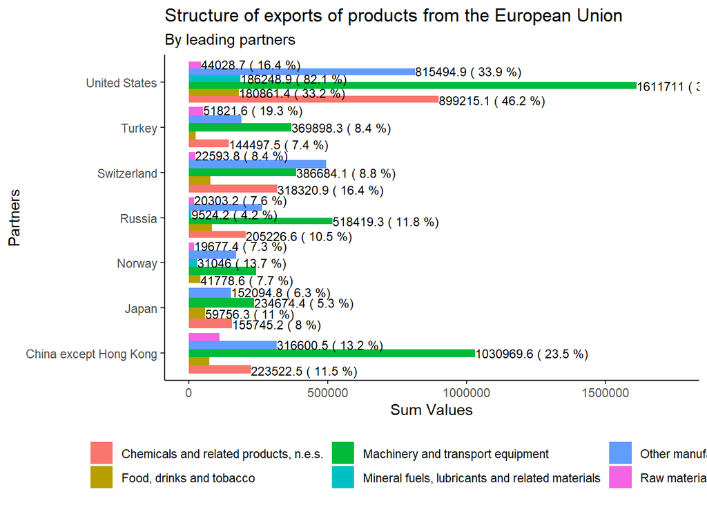

```r
ggplot(data = export, aes(x = values, y = partner, fill = sitc06)) +
  geom_col(position = "dodge") +
  geom_text(aes(label = paste(values, '(', percent, '%)')),
                size = 3.2,
                position = position_dodge(0.95),
                hjust = 0,
                check_overlap = TRUE) +
  labs(title = 'Structure of exports of products from the European Union',
       subtitle = 'By leading partners',
       x = 'Sum Values',
       y = 'Partners',
       fill = '') +
  xlim(c(0, 1750000)) +
  theme_classic() +
  theme(legend.position = "bottom")
```

К сожалению, почему-то график обрезается при формировании html, и я прям не знаю, как сделать так, чтобы он смотрелся лучше, мне кажется, что я перепробывал уже все, лучше не становится. Но вот я бы хотел прикрепить фото, как он отрисовывается в RStudio

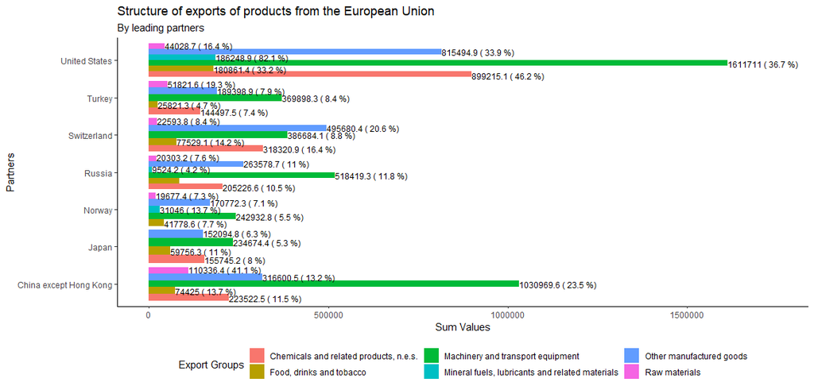